# Introduction and Essentials

Victoria Liebsch-Aljawahiri

2022-09-08

## Perparations

Load required libraries and custom functions.

```r
library(tidyverse)

# Functions
# Theme for plot
cool_theme <- function() {
  theme_minimal() +
  theme(
    text = element_text(family = "Bookman", color = "gray25"),
    plot.subtitle = element_text(size = 12),
    plot.caption = element_text(color = "gray30"),
    plot.background = element_rect(fill = "gray95"),
    plot.margin = unit(c(5, 10, 5, 10), units = "mm")
  )
}
```

## Question 1

A data frame has the variables of a data set as columns and the observations as rows. Basically, a data frame is a combination of data sets that contain different data types. The code below shows an example of a data frame. I have used the `head()` function to shorten how much of the data frame is printed out.

```r
head(iris)
```

|  | Sepal.Length | Sepal.Width | Petal.Length | Petal.Width | Species |
| --- | --- | --- | --- | --- | --- |
| 1 | 5.1 | 3.5 | 1.4 | 0.2 | setosa |
| 2 | 4.9 | 3.0 | 1.4 | 0.2 | setosa |
| 3 | 4.7 | 3.2 | 1.3 | 0.2 | setosa |
| 4 | 4.6 | 3.1 | 1.5 | 0.2 | setosa |
| 5 | 5.0 | 3.6 | 1.4 | 0.2 | setosa |
| 6 | 5.4 | 3.9 | 1.7 | 0.4 | setosa |

## Question 2

Create a data frame with 3 variables. The 3 variables should be cars, mpg, cost. The variable cars should contain 3 inputs. (Truck, Car, SUV) The variable mpg should contain 3 inputs (11, 30, 24) The variable cost should contain 3 inputs (45000,25000,35000) The data frame is printed below.

```r
cars <- c("Truck", "Car", "SUV")
mpg <- c(11, 30, 24)
cost <- c(45000, 25000, 35000)
vehicle_info <- data.frame(cars, mpg, cost)
vehicle_info
```

| cars | mpg | cost |
| --- | --- | --- |
| Truck | 11 | 45000 |
| Car | 30 | 25000 |
| SUV | 24 | 35000 |

## Question 2a

Select row 1 in column 3, what was selected? The first row of the `cost` variable. Select rows 1 through 3, what was selected? The entire data frame. Select the last column, what was selected? All rows of the `cost` variable.

```r
vehicle_info[1,3]
```

```
## [1] 45000
```

```r
vehicle_info[1:3,]
```

|  | cars | mpg | cost |
| --- | --- | --- | --- |
| 1 | Truck | 11 | 45000 |
| 2 | Car | 30 | 25000 |
| 3 | SUV | 24 | 35000 |

```r
vehicle_info[,3]
```

```
## [1] 45000 25000 35000
```

### Questions 3-5 will use the built-in dataset `mtcars`.

## Question 3

Display the first 3 rows of the data set and display the last 5 rows. Hint: `head()` and `tail()` are helpful functions.

```r
mtcars[1:3,]
```

|  | mpg | cyl | disp | hp | drat | wt | qsec | vs | am | gear | carb |
| --- | --- | --- | --- | --- | --- | --- | --- | --- | --- | --- | --- |
| Mazda RX4 | 21.0 | 6 | 160 | 110 | 3.90 | 2.620 | 16.46 | 0 | 1 | 4 | 4 |
| Mazda RX4 Wag | 21.0 | 6 | 160 | 110 | 3.90 | 2.875 | 17.02 | 0 | 1 | 4 | 4 |
| Datsun 710 | 22.8 | 4 | 108 | 93 | 3.85 | 2.320 | 18.61 | 1 | 1 | 4 | 1 |

```r
mtcars[28:32,]
```

|  | mpg | cyl | disp | hp | drat | wt | qsec | vs | am | gear | carb |
| --- | --- | --- | --- | --- | --- | --- | --- | --- | --- | --- | --- |
| Lotus Europa | 30.4 | 4 | 95.1 | 113 | 3.77 | 1.513 | 16.9 | 1 | 1 | 5 | 2 |
| Ford Pantera L | 15.8 | 8 | 351.0 | 264 | 4.22 | 3.170 | 14.5 | 0 | 1 | 5 | 4 |
| Ferrari Dino | 19.7 | 6 | 145.0 | 175 | 3.62 | 2.770 | 15.5 | 0 | 1 | 5 | 6 |
| Maserati Bora | 15.0 | 8 | 301.0 | 335 | 3.54 | 3.570 | 14.6 | 0 | 1 | 5 | 8 |
| Volvo 142E | 21.4 | 4 | 121.0 | 109 | 4.11 | 2.780 | 18.6 | 1 | 1 | 4 | 2 |

## Question 4

Display the column names of two categorical variables and two continuous variables.

```r
?mtcars
str(mtcars)
```

```
## 'data.frame':    32 obs. of  11 variables:
##  $ mpg : num  21 21 22.8 21.4 18.7 18.1 14.3 24.4 22.8 19.2 ...
##  $ cyl : num  6 6 4 6 8 6 8 4 4 6 ...
##  $ disp: num  160 160 108 258 360 ...
##  $ hp  : num  110 110 93 110 175 105 245 62 95 123 ...
##  $ drat: num  3.9 3.9 3.85 3.08 3.15 2.76 3.21 3.69 3.92 3.92 ...
##  $ wt  : num  2.62 2.88 2.32 3.21 3.44 ...
##  $ qsec: num  16.5 17 18.6 19.4 17 ...
##  $ vs  : num  0 0 1 1 0 1 0 1 1 1 ...
##  $ am  : num  1 1 1 0 0 0 0 0 0 0 ...
##  $ gear: num  4 4 4 3 3 3 3 4 4 4 ...
##  $ carb: num  4 4 1 1 2 1 4 2 2 4 ...
```

```r
colnames(mtcars)[2]   # categorical
```

```
## [1] "cyl"
```

```r
colnames(mtcars)[8]   # categorical
```

```
## [1] "vs"
```

```r
colnames(mtcars)[1]   # continuous
```

```
## [1] "mpg"
```

```r
colnames(mtcars)[3]   # continuous
```

```
## [1] "disp"
```

## Question 5

Type and execute the code `ggplot(mtcars, aes(x=disp, y=mpg))` in R studio. Does the code display a chart? If so, explain the chart that was displayed; if the chart is not displayed, indicate what is missing and how would you update the code to show a scatterplot showing the relationship between `disp` and `mpg`.

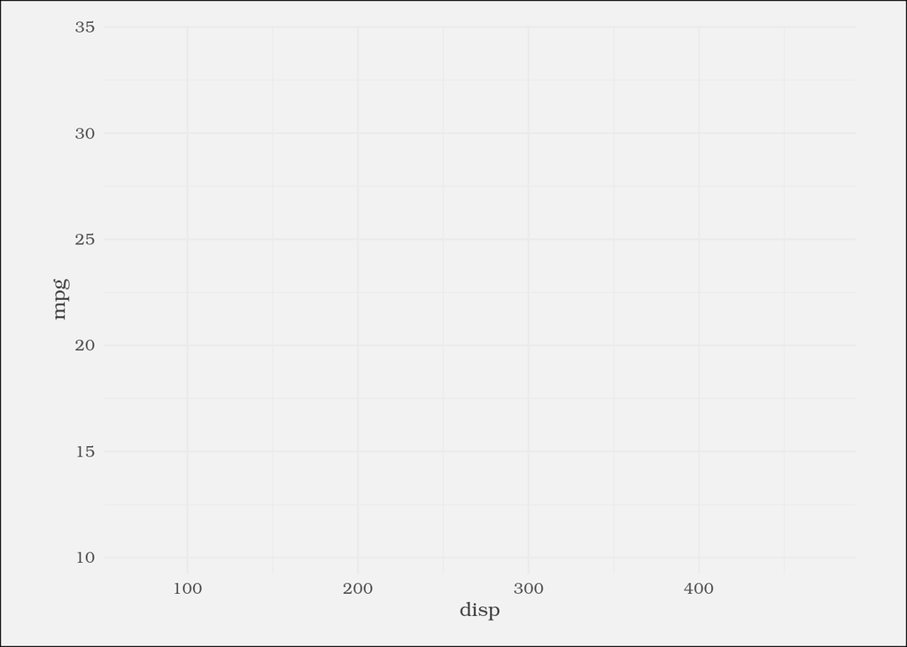

```r
ggplot(mtcars, aes(x=disp, y=mpg)) +
  cool_theme()
```

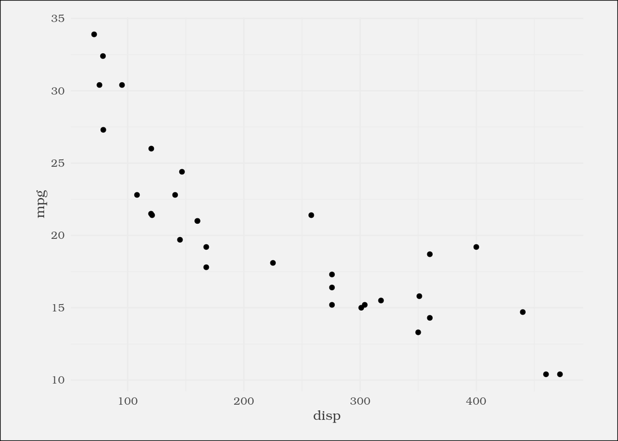

```r
ggplot(data = mtcars) +
  geom_point(mapping = aes(x = disp, y = mpg)) +
  cool_theme()
```

### Questions 6&7 will use the dataset `mpg`.

## Question 6

Create a scatterplot showing the relationship between `displ` and `hwy`. Color each point based on the number of cylinders (`cyl`). Explain the scatterplot.

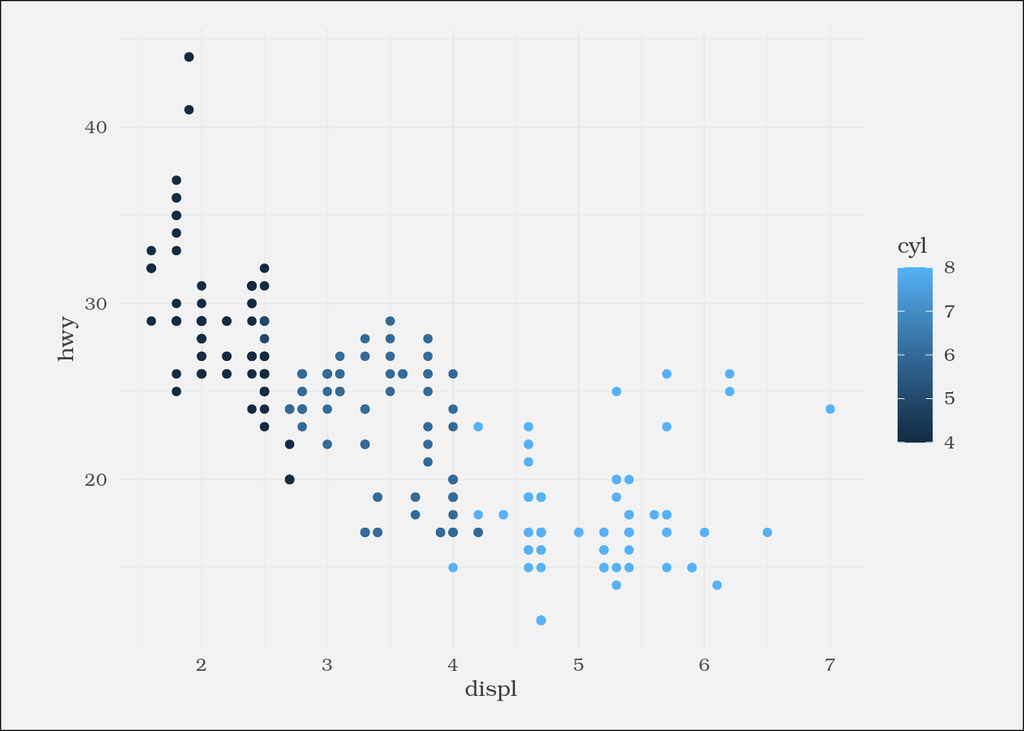

```r
ggplot(data = ggplot2::mpg) +
  geom_point(mapping = aes(x = displ, y = hwy, color = cyl)) +
  cool_theme()
```

This scatter plot shows the relationship between three variables (`hwy`, `displ`, `cyl`) while still using a 2-D x,y plane.

## Question 7

Copy the code for the scatter plot in question 6 and update it to apply facet_wrap using the `drv` column. What does the resulting charts indicate about rear wheel drive vehicles when compared to 4wd and front- wheel drive? Hint: use the help function to get more information on `facet_wrap`, e.g. `?facet_wrap`.

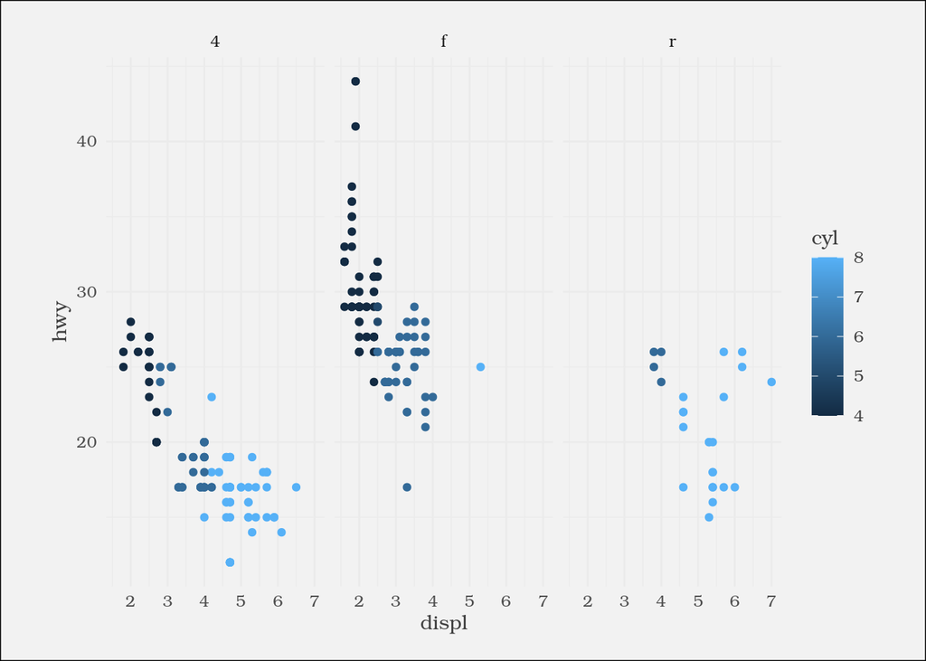

```r
ggplot(data = ggplot2::mpg) +
  geom_point(mapping = aes(x = displ, y = hwy, color = cyl)) +
  facet_wrap(vars(drv)) +
  cool_theme()
```

The charts reveal that rear wheel drive vehicles have the lowest variety of number of cylinders and tend to have more engine displacement (in liters), when compared to front and 4 wheel drive vehicles.